# Machine Learning Course Project

limrock

April 19, 2015

```
    This is my attempt at the Machine Learning course project. I have split the task into a number of sections:
```

- Library and data loading
- Cleaning the data
- Partitioning
- Model fitting
- Prediction & Evaluation
- Final submission

# Load libraries

I’m using the caret package to do all my ML work. I’m also loading the parallel library to help with the workload, as well as ggplot2 and gridExtra for some plots.

```r
suppressPackageStartupMessages(library(caret))
suppressPackageStartupMessages(library(gridExtra))
library(parallel)
library(ggplot2)
```

# Load data

Depending on whether data is downloaded previously, I fetch the data from the urls and load them up.

```r
if(!file.exists("pml-training.csv")) {
        trainURL <- "https://d396qusza40orc.cloudfront.net/predmachlearn/pml-training.csv"
        download.file(trainURL, dest="pml-training.csv", method="curl")
        testURL <- "https://d396qusza40orc.cloudfront.net/predmachlearn/pml-testing.csv"
        download.file(testURL, dest="pml-testing.csv", method="curl")
}
testData <- read.csv("pml-testing.csv", sep=",",header=T, as.is=T)    # test data
trainData <- read.csv("pml-training.csv",sep=",",header=T, as.is=T) # training data
```

# Clean the data

On of the most important tand time-consuming steps. Critical to the understanding o fthe project is the data content or lack thereof. A lot of time was wasted trying to model unclean data or data forms in the wrong class type.

```r
# convert any empty data to NA, then remove all NA.
trainData[trainData==""] <- NA
testData[testData == ""] <- NA
trainData <- trainData[, colSums(is.na(trainData)) == 0]
testData <- testData[, colSums(is.na(testData)) == 0]
# remove first 7 cols of user info
trainData <- trainData[,-c(1:7)]
testData <- testData[,-c(1:7)]
# finally set all variables to right class
classe <- as.factor(trainData$classe)
predictors <- as.data.frame(lapply(trainData[,1:52], as.numeric))
trainData <- cbind(predictors,classe)
```

# Partition training data into train & validation sets

I decided to partition my training set into both a training and a validation set. The validation is optional but I figured the training set is big enough anyways.

```r
# I'm splitting the training set into 2 parts:
# - the first to train the various models
# - the second to evaluate them
trainIndex = createDataPartition(trainData$classe, p = 0.6,list=FALSE)
training.data = trainData[trainIndex,]
training.eval = trainData[-trainIndex,]
```

# Model fitting

I selected 2 prediction models - boosting and random forest - to predict the outcomes for this project. Both types are available to run in the caret package. I tried to keep the parameters as similar as possible in both to compare later. I set a seed & optimise for all available cores.

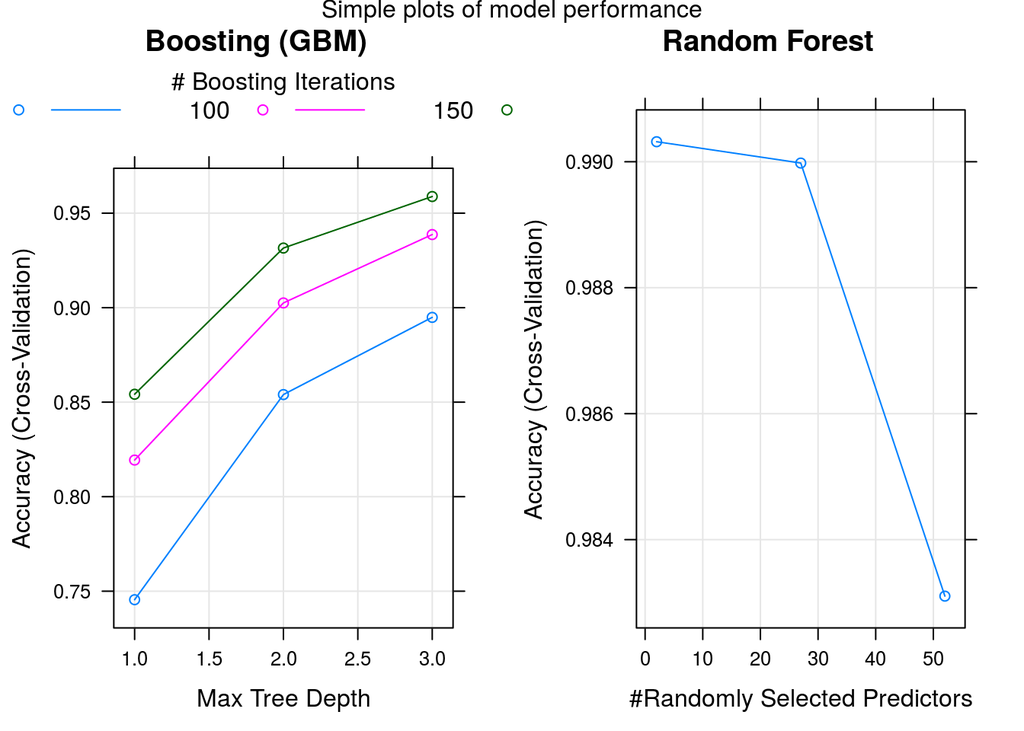

```r
options(mc.cores=detectCores())
set.seed(1973)
# 1. boosting
model1 <- train(classe ~ ., method="gbm", data=training.data, verbose=F,
                trControl = trainControl(method = "cv", number = 10))
# 2. random forest
model2 <- train(classe ~ ., method="rf", data=training.data, importance=T,
                trControl = trainControl(method = "cv", number = 10))

plot1 <- plot(model1, main="Boosting (GBM)")
plot2 <- plot(model2, main="Random Forest")
grid.arrange(plot1,plot2,ncol=2, main="Simple plots of model performance")
```

# A couple of plots to indicated the variables driving the models

With the random forest, the importance of each variable is split by classe. Boosting gives the overall importance. Only 12 variables exert agreater than 10% influence on the prediction of the overall outcome.

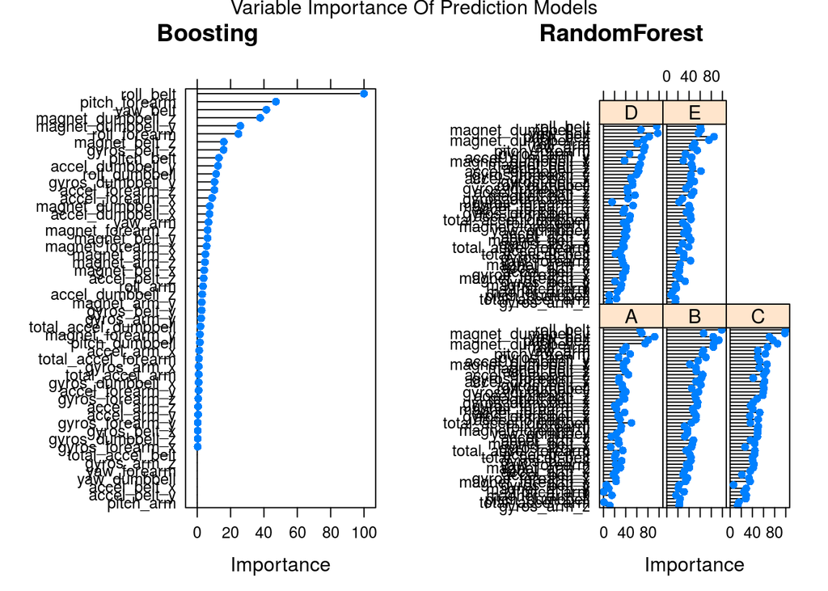

```r
varImpObj1 <- varImp(model1)
imp1 <- plot(varImpObj1,main="Boosting")
varImpObj2 <- varImp(model2)
imp2 <- plot(varImpObj2,main="RandomForest")
grid.arrange(imp1,imp2,ncol=2, main="Variable Importance Of Prediction Models")
```

# Prediction for the training set & validation sets.

```r
predict1 <- predict(model1, newdata=training.data)
confusionMatrix(predict1,training.data$classe)
```

```
## Confusion Matrix and Statistics
##
##           Reference
## Prediction    A    B    C    D    E
##          A 3315   57    0    2    2
##          B   23 2180   27    5    8
##          C    6   42 2010   56   10
##          D    2    0   16 1860   20
##          E    2    0    1    7 2125
##
## Overall Statistics
##
##                Accuracy : 0.9757
##                  95% CI : (0.9728, 0.9784)
##     No Information Rate : 0.2843
##     P-Value [Acc > NIR] : < 2.2e-16
##
##                   Kappa : 0.9693
##  Mcnemar's Test P-Value : 1.42e-11
##
## Statistics by Class:
##
##                      Class: A Class: B Class: C Class: D Class: E
## Sensitivity            0.9901   0.9566   0.9786   0.9637   0.9815
## Specificity            0.9928   0.9934   0.9883   0.9961   0.9990
## Pos Pred Value         0.9819   0.9719   0.9463   0.9800   0.9953
## Neg Pred Value         0.9961   0.9896   0.9954   0.9929   0.9959
## Prevalence             0.2843   0.1935   0.1744   0.1639   0.1838
## Detection Rate         0.2815   0.1851   0.1707   0.1579   0.1805
## Detection Prevalence   0.2867   0.1905   0.1804   0.1612   0.1813
## Balanced Accuracy      0.9915   0.9750   0.9834   0.9799   0.9902
```

```r
predict2 <- predict(model2, newdata=training.data)
confusionMatrix(predict2,training.data$classe)
```

```
## Confusion Matrix and Statistics
##
##           Reference
## Prediction    A    B    C    D    E
##          A 3348    0    0    0    0
##          B    0 2279    0    0    0
##          C    0    0 2054    0    0
##          D    0    0    0 1930    0
##          E    0    0    0    0 2165
##
## Overall Statistics
##
##                Accuracy : 1
##                  95% CI : (0.9997, 1)
##     No Information Rate : 0.2843
##     P-Value [Acc > NIR] : < 2.2e-16
##
##                   Kappa : 1
##  Mcnemar's Test P-Value : NA
##
## Statistics by Class:
##
##                      Class: A Class: B Class: C Class: D Class: E
## Sensitivity            1.0000   1.0000   1.0000   1.0000   1.0000
## Specificity            1.0000   1.0000   1.0000   1.0000   1.0000
## Pos Pred Value         1.0000   1.0000   1.0000   1.0000   1.0000
## Neg Pred Value         1.0000   1.0000   1.0000   1.0000   1.0000
## Prevalence             0.2843   0.1935   0.1744   0.1639   0.1838
## Detection Rate         0.2843   0.1935   0.1744   0.1639   0.1838
## Detection Prevalence   0.2843   0.1935   0.1744   0.1639   0.1838
## Balanced Accuracy      1.0000   1.0000   1.0000   1.0000   1.0000
```

```r
# Now for the validation set.
eval1 <- predict(model1, newdata=training.eval)
confusionMatrix(eval1,training.eval$classe)
```

```
## Confusion Matrix and Statistics
##
##           Reference
## Prediction    A    B    C    D    E
##          A 2205   64    0    0    2
##          B   19 1405   36    4   20
##          C    6   48 1316   25   11
##          D    2    1   15 1249   14
##          E    0    0    1    8 1395
##
## Overall Statistics
##
##                Accuracy : 0.9648
##                  95% CI : (0.9605, 0.9688)
##     No Information Rate : 0.2845
##     P-Value [Acc > NIR] : < 2.2e-16
##
##                   Kappa : 0.9555
##  Mcnemar's Test P-Value : 3.742e-11
##
## Statistics by Class:
##
##                      Class: A Class: B Class: C Class: D Class: E
## Sensitivity            0.9879   0.9256   0.9620   0.9712   0.9674
## Specificity            0.9882   0.9875   0.9861   0.9951   0.9986
## Pos Pred Value         0.9709   0.9468   0.9360   0.9750   0.9936
## Neg Pred Value         0.9952   0.9822   0.9919   0.9944   0.9927
## Prevalence             0.2845   0.1935   0.1744   0.1639   0.1838
## Detection Rate         0.2810   0.1791   0.1677   0.1592   0.1778
## Detection Prevalence   0.2894   0.1891   0.1792   0.1633   0.1789
## Balanced Accuracy      0.9881   0.9565   0.9740   0.9832   0.9830
```

```r
eval2 <- predict(model2, newdata=training.eval)
confusionMatrix(eval2,training.eval$classe)
```

```
## Confusion Matrix and Statistics
##
##           Reference
## Prediction    A    B    C    D    E
##          A 2231    8    0    0    0
##          B    0 1508   13    0    0
##          C    0    2 1349   18    2
##          D    0    0    6 1265    2
##          E    1    0    0    3 1438
##
## Overall Statistics
##
##                Accuracy : 0.993
##                  95% CI : (0.9909, 0.9947)
##     No Information Rate : 0.2845
##     P-Value [Acc > NIR] : < 2.2e-16
##
##                   Kappa : 0.9911
##  Mcnemar's Test P-Value : NA
##
## Statistics by Class:
##
##                      Class: A Class: B Class: C Class: D Class: E
## Sensitivity            0.9996   0.9934   0.9861   0.9837   0.9972
## Specificity            0.9986   0.9979   0.9966   0.9988   0.9994
## Pos Pred Value         0.9964   0.9915   0.9840   0.9937   0.9972
## Neg Pred Value         0.9998   0.9984   0.9971   0.9968   0.9994
## Prevalence             0.2845   0.1935   0.1744   0.1639   0.1838
## Detection Rate         0.2843   0.1922   0.1719   0.1612   0.1833
## Detection Prevalence   0.2854   0.1939   0.1747   0.1622   0.1838
## Balanced Accuracy      0.9991   0.9957   0.9914   0.9912   0.9983
```

# Out-Of-Sample Error

OOS error should be less than 1% if the accuracy in the second validation model is true (99%).

```r
OOS_Error.accuracy <- sum(eval2 == training.eval$classe)/length(eval2)
OOS_Error <- (1 - OOS_Error.accuracy)*100
OOS_Erros_Percent <- paste("Out Of Sample Error: ",round(OOS_Error, digits = 2), "%",sep="")
print(OOS_Erros_Percent)
```

```
## [1] "Out Of Sample Error: 0.7%"
```

# Project Submission

```r
pml_write_files = function(x){
        n = length(x)
        for(i in 1:n){
                filename = paste0("problem_id_",i,".txt")
                write.table(x[i],file=filename,quote=FALSE,row.names=FALSE,col.names=FALSE)
        }
}

# Answers
feature_set <- colnames(predictors)
tesData <- testData[,colnames(feature_set)]
answers <- predict(model2, newdata=testData)

pml_write_files(answers)
```